# Data Analysis Assignment

# This part is to stimulate the data

```r
# load required data
library(ggplot2)
library(dplyr)
library(tidyr)

# stimulate the data

set.seed(20)

# create the total number of participants for this data frame
nsubs = 34 # participants

# example with 2 subpop
nGroups = 2
nSubsGroup = 18

# Condition
nEnvi = 2 # environment conditions
EnviLabels <- c("Urban", "Rural")
EnvPerParticipant = 17


df <- data.frame(Participant=rep(0,nsubs),
                 Environment=rep("NA",nsubs),
                 ReactionTimeOverall=rep(0,nsubs),
                 ReactionTimeIncorOverall=rep(0,nsubs),
                 ReactionTime90=rep(0,nsubs),
                 IncoReactionTime90=rep(0,nsubs),
                 ReactionTime45=rep(0,nsubs),
                 IncoReactionTime45=rep(0,nsubs),
                 AccuracyOverall=rep(0,nsubs),
                 Accuracy90=rep(0,nsubs),
                 Accuracy45=rep(0,nsubs),
                 Age=rep(0,nsubs),
                 stringsAsFactors = TRUE)

head(df)
```

|  | Participant | Environment | ReactionTimeOverall | ReactionTimeIncorOverall | ReactionTime90 | IncoReactionTime90 | ReactionTime45 | IncoReactionTime45 | AccuracyOverall | Accuracy90 | Accuracy45 | Age |
| --- | --- | --- | --- | --- | --- | --- | --- | --- | --- | --- | --- | --- |
| 1 | 0 | NA | 0 | 0 | 0 | 0 | 0 | 0 | 0 | 0 | 0 | 0 |
| 2 | 0 | NA | 0 | 0 | 0 | 0 | 0 | 0 | 0 | 0 | 0 | 0 |
| 3 | 0 | NA | 0 | 0 | 0 | 0 | 0 | 0 | 0 | 0 | 0 | 0 |
| 4 | 0 | NA | 0 | 0 | 0 | 0 | 0 | 0 | 0 | 0 | 0 | 0 |
| 5 | 0 | NA | 0 | 0 | 0 | 0 | 0 | 0 | 0 | 0 | 0 | 0 |
| 6 | 0 | NA | 0 | 0 | 0 | 0 | 0 | 0 | 0 | 0 | 0 | 0 |

```r
# Participant Data
df$Participant <- seq(1,nsubs)

# Age of Participants
df$Age = sample(18:50, nsubs, replace = TRUE)

# Environment Data
en1 <- rep(EnviLabels[1], times = nsubs/2)
en2 <- rep(EnviLabels[2], times = nsubs/2)
envs <- c(en1,en2)
envs_shuffle <- sample(envs)
df$Environment <- rep(envs_shuffle)


df$ReactionTimeOverall = rnorm(nsubs, mean = 700, sd = 100)
df$ReactionTime90 = rnorm(nsubs, mean = 700, sd = 100)
df$ReactionTimeIncorOverall = rnorm(nsubs, mean = 800, sd = 100)
df$IncoReactionTime90 = rnorm(nsubs, mean = 750, sd = 100)
df$ReactionTime45 = rnorm(nsubs, mean = 720, sd = 100)
df$IncoReactionTime45 = rnorm(nsubs, mean = 770, sd = 100)

# Adjusting the reaction times for 90 degrees based on the environment condition
df$ReactionTime90[df$Environment == "Urban"] = df$ReactionTime90[df$Environment == "Urban"] - 200  # Urban with 90 degrees is faster
df$ReactionTime90[df$Environment == "Rural"] = df$ReactionTime90[df$Environment == "Rural"] + 200  # Rural with 90 degrees is slower

# Adjusting the incorrect reaction times for 90 degrees based on environment condition
df$IncoReactionTime90[df$Environment == "Urban"] = df$IncoReactionTime90[df$Environment == "Urban"] - 150  # Urban incorrect RT for 90 degrees is faster
df$IncoReactionTime90[df$Environment == "Rural"] = df$IncoReactionTime90[df$Environment == "Rural"] + 175  # Rural incorrect RT for 90 degrees is slower

# Adjusting the reaction times for 45 degrees based on the environment condition
df$ReactionTime45[df$Environment == "Urban"] = df$ReactionTime45[df$Environment == "Urban"] - 200  # Urban with 45 degrees is faster
df$ReactionTime45[df$Environment == "Rural"] = df$ReactionTime45[df$Environment == "Rural"] + 200  # Rural with 45 degrees is slower

# Adjusting the incorrect reaction times for 45 degrees based on environment condition
df$IncoReactionTime45[df$Environment == "Urban"] = df$IncoReactionTime45[df$Environment == "Urban"] - 200  # Urban incoherent RT for 45 degrees is faster
df$IncoReactionTime45[df$Environment == "Rural"] = df$IncoReactionTime45[df$Environment == "Rural"] + 200  # Rural incoherent RT for 45 degrees is slower


# This will give accuracy values as percentages between the given values
df$AccuracyOverall = runif(nsubs, min=60, max=100)
df$Accuracy90 = runif(nsubs, min=80, max=100)
df$Accuracy45 = runif(nsubs, min=60, max=100)

# Adjust accuracy based on environment condition
df$AccuracyOverall[df$Environment == "Urban"] = df$AccuracyOverall[df$Environment == "Urban"] + 5  # Urban is 5% more accurate
df$Accuracy90[df$Environment == "Urban"] = df$Accuracy90[df$Environment == "Urban"] + 5
df$Accuracy45[df$Environment == "Urban"] = df$Accuracy45[df$Environment == "Urban"] + 5

df$AccuracyOverall[df$Environment == "Rural"] = df$AccuracyOverall[df$Environment == "Rural"] - 5  # Rural is 5% less accurate
df$Accuracy90[df$Environment == "Rural"] = df$Accuracy90[df$Environment == "Rural"] - 5
df$Accuracy45[df$Environment == "Rural"] = df$Accuracy45[df$Environment == "Rural"] - 5

# This is to make sure that accuracy stays between 0% and 100%
df$AccuracyOverall <- pmax(pmin(df$AccuracyOverall, 100), 0)
df$Accuracy90 <- pmax(pmin(df$Accuracy90, 100), 0)
df$Accuracy45 <- pmax(pmin(df$Accuracy45, 100), 0)
```

# Data Cleaning

```r
head(df) # Just to make sure that the data looks good
```

|  | Participant | Environment | ReactionTimeOverall | ReactionTimeIncorOverall | ReactionTime90 | IncoReactionTime90 | ReactionTime45 | IncoReactionTime45 | AccuracyOverall | Accuracy90 | Accuracy45 | Age |
| --- | --- | --- | --- | --- | --- | --- | --- | --- | --- | --- | --- | --- |
| 1 | 1 | Urban | 593.0338 | 741.3268 | 477.4394 | 632.5090 | 433.3510 | 505.3699 | 90.07011 | 95.71217 | 82.98050 | 19 |
| 2 | 2 | Rural | 790.8884 | 733.4269 | 1021.7116 | 973.0137 | 1156.6811 | 864.3125 | 92.70765 | 76.74829 | 74.20135 | 46 |
| 3 | 3 | Rural | 568.2493 | 829.5353 | 970.0920 | 976.4210 | 853.1675 | 1017.0887 | 65.57649 | 93.03982 | 65.30639 | 47 |
| 4 | 4 | Rural | 765.5430 | 690.7559 | 991.1970 | 983.9252 | 1020.8678 | 967.9794 | 92.71364 | 85.55127 | 93.98056 | 20 |
| 5 | 5 | Rural | 633.9628 | 892.6901 | 910.9517 | 869.1406 | 742.8266 | 879.7880 | 93.87645 | 89.53543 | 61.51464 | 31 |
| 6 | 6 | Rural | 799.1581 | 768.5933 | 889.0008 | 802.0482 | 968.7406 | 988.2157 | 60.58656 | 77.98315 | 62.05208 | 25 |

```r
summary(df) #can see all the basic information including the mean median, etc.
```

```
  Participant    Environment        ReactionTimeOverall ReactionTimeIncorOverall
 Min.   : 1.00   Length:34          Min.   :503.2       Min.   :620.7
 1st Qu.: 9.25   Class :character   1st Qu.:659.0       1st Qu.:763.5
 Median :17.50   Mode  :character   Median :710.5       Median :828.7
 Mean   :17.50                      Mean   :716.9       Mean   :822.0
 3rd Qu.:25.75                      3rd Qu.:784.6       3rd Qu.:895.9
 Max.   :34.00                      Max.   :920.8       Max.   :991.4
 ReactionTime90   IncoReactionTime90 ReactionTime45   IncoReactionTime45 AccuracyOverall
 Min.   : 321.1   Min.   : 422.6     Min.   : 289.0   Min.   : 461.7     Min.   : 55.23
 1st Qu.: 544.6   1st Qu.: 625.1     1st Qu.: 525.2   1st Qu.: 539.5     1st Qu.: 68.85
 Median : 718.3   Median : 752.2     Median : 764.8   Median : 765.2     Median : 79.38
 Mean   : 701.7   Mean   : 761.3     Mean   : 724.0   Mean   : 762.8     Mean   : 80.49
 3rd Qu.: 876.9   3rd Qu.: 939.8     3rd Qu.: 891.3   3rd Qu.: 987.9     3rd Qu.: 92.75
 Max.   :1021.7   Max.   :1100.9     Max.   :1156.7   Max.   :1107.9     Max.   :100.00
   Accuracy90       Accuracy45          Age
 Min.   : 75.62   Min.   : 61.51   Min.   :19.00
 1st Qu.: 86.01   1st Qu.: 71.31   1st Qu.:23.00
 Median : 91.39   Median : 80.08   Median :28.50
 Mean   : 90.26   Mean   : 81.10   Mean   :31.26
 3rd Qu.: 96.93   3rd Qu.: 90.29   3rd Qu.:38.00
 Max.   :100.00   Max.   :100.00   Max.   :50.00
```

# Data exploration

```r
# explore the summary

# THE MEAN VALUES
meanRT <- mean(df$ReactionTimeOverall) # Mean for the reaction time for the correct trials
meanIncRT <- mean(df$ReactionTimeIncorOverall) # Mean for the reaction time for the incorrect trials
meanRT_90 <- mean(df$ReactionTime90) # Mean for the correct 90 degree rotations --> reaction time
meanRT_45 <- mean(df$ReactionTime45) # Mean for the correct 45 degree rotations --> reaction time
meanIncRT_90 <- mean(df$IncoReactionTime90) # Mean for the incorrect 90 degree rotations --> reaction time
meanIncRT_45 <- mean(df$IncoReactionTime45) # Mean for the incorrect 45 degree rotations --> reaction time
meanAcc <- mean(df$AccuracyOverall) # Mean for accuracy overall
meanAcc_90 <- mean(df$Accuracy90) # Mean for percent accuracy in 90 degree trials
meanAcc_45 <- mean(df$Accuracy45) # Mean for percent accuracy in 45 degree trials
meanAge <- mean(df$Age) # Mean for age

print(meanRT)
```

```
[1] 716.9194
```

```r
print(meanIncRT)
```

```
[1] 822.034
```

```r
print(meanRT_90)
```

```
[1] 701.7087
```

```r
print(meanRT_45)
```

```
[1] 724.0147
```

```r
print(meanIncRT_90)
```

```
[1] 761.3081
```

```r
print(meanIncRT_45)
```

```
[1] 762.8431
```

```r
print(meanAcc)
```

```
[1] 80.48629
```

```r
print(meanAcc_90)
```

```
[1] 90.2583
```

```r
print(meanAcc_45)
```

```
[1] 81.09713
```

```r
print(meanAge)
```

```
[1] 31.26471
```

```r
# THE STANDARD DEVIATION VALUES
sdRT <- sd(df$ReactionTimeOverall) # standard deviation for the reaction time for the correct trials
sdIncRT <- sd(df$ReactionTimeIncorOverall) # standard deviation for the reaction time for the incorrect trials
sdRT_90 <- sd(df$ReactionTime90) # standard deviation for the correct 90 degree rotations
sdRT_45 <- sd(df$ReactionTime45) # standard deviation for the correct 45 degree rotations
sdIncRT_90 <- sd(df$IncoReactionTime90) # standard deviation for the incorrect 90 degree rotations
sdIncRT_45 <- sd(df$IncoReactionTime45) # standard deviation for the incorrect 45 degree rotations
sdAcc <- sd(df$AccuracyOverall) # standard deviation for accuracy overall
sdAcc_90 <- sd(df$Accuracy90) # standard deviation for percent accuracy in 90 degree trials
sdAcc_45 <- sd(df$Accuracy45) # standard deviation for percent accuracy in 45 degree trials
sdAge <- sd(df$Age) # standard deviation for age

print(sdRT)
```

```
[1] 93.81614
```

```r
print(sdIncRT)
```

```
[1] 91.10403
```

```r
print(sdRT_90)
```

```
[1] 210.1552
```

```r
print(sdRT_45)
```

```
[1] 221.5936
```

```r
print(sdIncRT_90)
```

```
[1] 187.3342
```

```r
print(sdIncRT_45)
```

```
[1] 225.7301
```

```r
print(sdAcc)
```

```
[1] 14.15388
```

```r
print(sdAcc_90)
```

```
[1] 7.316108
```

```r
print(sdAcc_45)
```

```
[1] 12.12257
```

```r
print(sdAge)
```

```
[1] 9.560997
```

# Checking for Normality:

## p-value < 0.05: Data are not normally distributed.

## p-value ≥ 0.05: Data are likely normally distributed

## If data is not normal, then alternative testing is required.

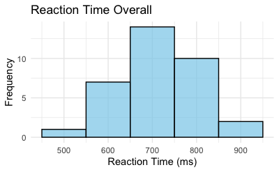

```r
# Check normality using histograms, and Shapiro-Wilk test

# Reaction Time Overall Histogram
ggplot(df, aes(x = ReactionTimeOverall)) +
  geom_histogram(binwidth = 100, fill = "skyblue", color = "black", alpha = 0.7) +
  labs(title = "Reaction Time Overall", x = "Reaction Time (ms)", y = "Frequency") +
  theme_minimal()
```

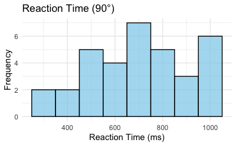

```r
# Reaction Time 90° Histogram
ggplot(df, aes(x = ReactionTime90)) +
  geom_histogram(binwidth = 100, fill = "skyblue", color = "black", alpha = 0.7) +
  labs(title = "Reaction Time (90°)", x = "Reaction Time (ms)", y = "Frequency") +
  theme_minimal()
```

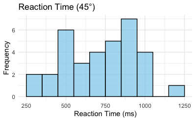

```r
# Reaction Time 45° Histogram
ggplot(df, aes(x = ReactionTime45)) +
  geom_histogram(binwidth = 100, fill = "skyblue", color = "black", alpha = 0.7) +
  labs(title = "Reaction Time (45°)", x = "Reaction Time (ms)", y = "Frequency") +
  theme_minimal()
```

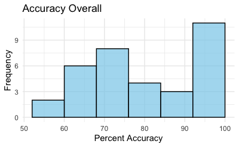

```r
# Accuracy Overall Histogram
ggplot(df, aes(x = AccuracyOverall)) +
  geom_histogram(binwidth = 8, fill = "skyblue", color = "black", alpha = 0.7) +
  labs(title = "Accuracy Overall", x = "Percent Accuracy", y = "Frequency") +
  theme_minimal()
```

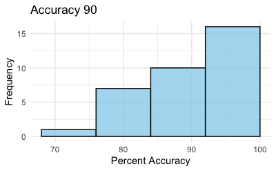

```r
# Accuracy 90° Histogram
ggplot(df, aes(x = Accuracy90)) +
  geom_histogram(binwidth = 8, fill = "skyblue", color = "black", alpha = 0.7) +
  labs(title = "Accuracy 90", x = "Percent Accuracy", y = "Frequency") +
  theme_minimal()
```

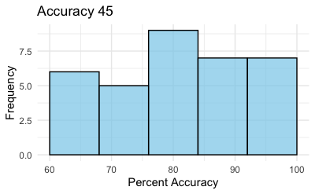

```r
# Accuracy 45° Histogram
ggplot(df, aes(x = Accuracy45)) +
  geom_histogram(binwidth = 8, fill = "skyblue", color = "black", alpha = 0.7) +
  labs(title = "Accuracy 45", x = "Percent Accuracy", y = "Frequency") +
  theme_minimal()
```

```r
# Shapiro-Wilk Test for Normality
shapiro.test(df$ReactionTimeOverall)
```

```
    Shapiro-Wilk normality test

data:  df$ReactionTimeOverall
W = 0.99017, p-value = 0.987
```

```r
shapiro.test(df$ReactionTime90)
```

```
    Shapiro-Wilk normality test

data:  df$ReactionTime90
W = 0.95526, p-value = 0.1763
```

```r
shapiro.test(df$ReactionTime45)
```

```
    Shapiro-Wilk normality test

data:  df$ReactionTime45
W = 0.9644, p-value = 0.3251
```

```r
shapiro.test(df$AccuracyOverall)
```

```
    Shapiro-Wilk normality test

data:  df$AccuracyOverall
W = 0.92015, p-value = 0.01631
```

```r
shapiro.test(df$Accuracy90)
```

```
    Shapiro-Wilk normality test

data:  df$Accuracy90
W = 0.92345, p-value = 0.02024
```

```r
shapiro.test(df$Accuracy45)
```

```
    Shapiro-Wilk normality test

data:  df$Accuracy45
W = 0.9495, p-value = 0.1186
```

```r
# p-value < 0.05: Data are not normally distributed.
# p-value ≥ 0.05: Data are likely normally distributed
```

```r
# Add a small constant to handle zero values
df$AccuracyOverall_log <- log(df$AccuracyOverall + 1)
df$Accuracy90_log <- log(df$Accuracy90 + 1)
df$Accuracy45_log <- log(df$Accuracy45 + 1)

# Check normality again
shapiro.test(df$AccuracyOverall_log)
```

```
    Shapiro-Wilk normality test

data:  df$AccuracyOverall_log
W = 0.92589, p-value = 0.02379
```

```r
shapiro.test(df$Accuracy90_log)
```

```
    Shapiro-Wilk normality test

data:  df$Accuracy90_log
W = 0.91421, p-value = 0.01112
```

```r
shapiro.test(df$Accuracy45_log)
```

```
    Shapiro-Wilk normality test

data:  df$Accuracy45_log
W = 0.94792, p-value = 0.1064
```

## After checking the log transformation, the overall accuracy and the accuracy for the 90 degree condition are still not normal. Thus we will proceede with non parametric tests for those variables.

# Non-Parametric Test:

```r
# Non-Parametric Test --> Mann-Whitney U Test

# For overall accuracy
wilcox.test(AccuracyOverall_log ~ Environment, data = df)
```

```
    Wilcoxon rank sum test with continuity correction

data:  AccuracyOverall_log by Environment
W = 86, p-value = 0.04542
alternative hypothesis: true location shift is not equal to 0
```

```r
# For accuracy of 90 degrees
wilcox.test(Accuracy90_log ~ Environment, data = df)
```

```
    Wilcoxon rank sum test with continuity correction

data:  Accuracy90_log by Environment
W = 17, p-value = 1.216e-05
alternative hypothesis: true location shift is not equal to 0
```

# Non Parametric Test Results:

## Accuracy Overall: p-value = 0.04542.

### This p-value suggests a significant difference between the Urban and Rural environments in terms of the overall accuracy.

## Accuracy 90: p-value = 1.216e-05.

### The very small p-value indicates a highly significant difference in accuracy at the 90° angle between the two environments. This result strongly suggests that there is a difference in performance between Urban and Rural environments for this specific angle.

# ANOVA:

```r
############################################################
# ANOVA for Reaction Time
# Reaction Time (45°)
anova_RT_45 <- aov(ReactionTime45 ~ Environment, data = df)

# Reaction Time (90°)
anova_RT_90 <- aov(ReactionTime90 ~ Environment, data = df)

# Overall Reaction Time (if needed)
anova_RT_overall <- aov(ReactionTimeOverall ~ Environment, data = df)

summary(anova_RT_45)
```

```
            Df  Sum Sq Mean Sq F value   Pr(>F)
Environment  1 1084683 1084683   64.79 3.44e-09 ***
Residuals   32  535739   16742
---
Signif. codes:  0 ‘***’ 0.001 ‘**’ 0.01 ‘*’ 0.05 ‘.’ 0.1 ‘ ’ 1
```

```r
summary(anova_RT_90)
```

```
            Df  Sum Sq Mean Sq F value  Pr(>F)
Environment  1 1074021 1074021   89.64 8.5e-11 ***
Residuals   32  383430   11982
---
Signif. codes:  0 ‘***’ 0.001 ‘**’ 0.01 ‘*’ 0.05 ‘.’ 0.1 ‘ ’ 1
```

```r
summary(anova_RT_overall)
```

```
            Df Sum Sq Mean Sq F value Pr(>F)
Environment  1  17720   17720   2.079  0.159
Residuals   32 272729    8523
```

```r
############################################################
# ANOVA for accuracy (45 degrees only since that was the only normal one)
anova_Acc_45 <- aov(Accuracy45_log ~ Environment, data = df)
summary(anova_Acc_45)
```

```
            Df Sum Sq Mean Sq F value  Pr(>F)
Environment  1 0.1466 0.14663   7.897 0.00838 **
Residuals   32 0.5942 0.01857
---
Signif. codes:  0 ‘***’ 0.001 ‘**’ 0.01 ‘*’ 0.05 ‘.’ 0.1 ‘ ’ 1
```

```r
############################################################
# ANOVA for interactions --> have to first convert it to long format in order to run the two way anova for the interactions
df_long <- df %>%
  pivot_longer(cols = c(ReactionTime45, ReactionTime90),
               names_to = "Angle", values_to = "ReactionTime") %>%
  mutate(Angle = ifelse(Angle == "ReactionTime45", 45, 90))  # Convert to numeric

anova_RT_interaction <- aov(ReactionTime ~ Environment * Angle, data = df_long)
summary(anova_RT_interaction)
```

```
                  Df  Sum Sq Mean Sq F value Pr(>F)
Environment        1 2158692 2158692 150.306 <2e-16 ***
Angle              1    8458    8458   0.589  0.446
Environment:Angle  1      13      13   0.001  0.976
Residuals         64  919170   14362
---
Signif. codes:  0 ‘***’ 0.001 ‘**’ 0.01 ‘*’ 0.05 ‘.’ 0.1 ‘ ’ 1
```

# ANOVA RESULTS

## Reaction Time ANOVA:

### - 45° Angle (Overall): Significant difference in reaction time between the environments for the 45° angle.

### - 90° Angle (Overall): Significant difference in reaction time between the environments for the 90° angle.

### - Overall Reaction Time: No significant effect of environment on overall reaction time.

## Accuracy ANOVA for 45°:

### Environment: Significant difference in accuracy between the two environments for the 45° angle.

## Interaction ANOVA:

### The significant effect on reaction time is due to Environment, but Angle and its interaction with Environment do not seem to have a significant impact.

# Main Results:

## Reaction Time:

### There is a strong significant difference in reaction time between Urban and Rural environments for both the 45° and 90° angles, but no significant difference for Overall Reaction Time. This suggests that the effect is specific to the angle conditions rather than the overall measure.

## Accuracy:

### There is a significant effect of environment on accuracy for the 45° angle, indicating that the environment influences how accurately participants perform at this angle.

# Post Hoc Test

```r
# Reaction Time (45°)
pairwise_RT_45 <- pairwise.t.test(df$ReactionTime45, df$Environment, p.adjust.method = "bonferroni")
# Reaction Time (90°)
pairwise_RT_90 <- pairwise.t.test(df$ReactionTime90, df$Environment, p.adjust.method = "bonferroni")
# Accuracy (45°)
pairwise_Acc_45 <- pairwise.t.test(df$Accuracy45_log, df$Environment, p.adjust.method = "bonferroni")


print(pairwise_RT_45)
```

```
    Pairwise comparisons using t tests with pooled SD

data:  df$ReactionTime45 and df$Environment

      Rural
Urban 3.4e-09

P value adjustment method: bonferroni
```

```r
print(pairwise_RT_90)
```

```
    Pairwise comparisons using t tests with pooled SD

data:  df$ReactionTime90 and df$Environment

      Rural
Urban 8.5e-11

P value adjustment method: bonferroni
```

```r
print(pairwise_Acc_45)
```

```
    Pairwise comparisons using t tests with pooled SD

data:  df$Accuracy45_log and df$Environment

      Rural
Urban 0.0084

P value adjustment method: bonferroni
```